# Recommending Movie based on Genre,Demographic and User likes

Naitik Shukla

November 12, 2017

- Preprocessed split data is already available in *movielikes_genre_train.txt/movielikes_genre_test.txt* created using *“data_preprocessing.r”*
- Below code will run apriori for finding the association and then testing the rules generated over unseen test data.
- Final objective is to take multiple predescendent in rules and match with subset of basket to find antecedents, which has been done below using *subset* and *Reduce*

## Load the required package

```r
library(arules)
library(arulesViz)
```

## Load train and test file which include genre details

```r
setwd("C:/Users/naitikshukla/Downloads/fin")
train_genre = read.transactions('movielikes_genre_train.txt', 'single', cols = c('UserID', 'movie'))
test_genre = read.transactions('movielikes_genre_test.txt', 'single', cols = c('UserID', 'movie'))
```

## find number of user and convert test transactions to list

```r
test_genre.list = as(test_genre, 'list')
test_genre.count = length(test_genre)
```

## Summary and Visualization of data loaded(train)

```r
summary(train_genre)
```

```
transactions as itemMatrix in sparse format with
 754 rows (elements/itemsets/transactions) and
 1662 columns (items) and a density of 0.06466036

most frequent items:
  Drama     m50    m100    m181    m258 (Other)
    465     462     404     399     399   78900

element (itemset/transaction) length distribution:
sizes
 21  22  23  24  25  26  27  28  29  30  31  32  33  34  35  36  37  38  39
 25  17  20  15  15  14  18  16  13   9  12   6   9  13   7   6   7   7   8
 40  41  42  43  44  45  46  47  48  49  50  51  52  53  54  55  56  57  58
  5   5   5   5   8   6   3   7  10   6   2   4  11   3   8   3   5   4   5
 59  60  61  62  63  64  65  66  67  68  69  70  72  73  74  75  76  77  78
  7   4   2   2   6   5   3   4   4   3   3   1   6   2   3   3   6   4   2
 80  81  82  83  84  85  86  87  88  90  91  93  94  95  96  97  98  99 101
  3   4   4   1   3   2   1   2   2   4   1   2   4   1   2   2   2   3   2
102 103 104 105 106 107 108 109 110 111 112 113 114 115 116 118 119 120 121
  3   5   2   3   4   4   4   3   4   2   2   1   1   2   4   1   3   1   3
122 123 125 126 127 128 129 130 131 132 133 134 135 136 137 138 139 140 141
  5   2   4   1   1   3   2   2   1   2   2   3   1   5   2   2   2   2   2
142 143 144 146 147 148 149 150 151 152 154 155 156 157 159 160 161 162 163
  2   2   3   2   1   3   3   2   4   2   1   4   3   2   1   3   2   2   2
164 166 167 168 169 172 173 174 175 176 178 180 182 184 185 186 188 189 190
  1   1   1   1   3   2   1   1   1   2   1   1   2   3   3   2   3   1   2
191 192 193 196 197 198 200 201 203 205 207 208 209 210 212 214 216 217 218
  1   1   1   1   2   2   1   1   1   2   3   1   1   1   1   1   1   3   2
219 222 225 226 227 229 232 233 234 235 237 238 239 241 242 243 246 250 252
  1   1   2   2   1   1   2   1   2   1   3   1   1   1   1   1   2   1   2
255 260 261 263 264 269 270 272 273 274 275 276 279 284 285 289 294 295 297
  1   1   1   1   2   1   2   1   1   2   1   1   1   1   1   2   1   1   1
298 301 305 306 307 308 312 317 318 319 320 324 327 328 329 333 334 335 343
  1   1   1   2   1   1   2   1   1   1   1   1   1   1   1   1   1   1   1
354 358 359 361 363 366 369 376 380 383 387 388 389 398 401 404 415 435 436
  1   1   1   1   1   1   1   1   1   1   1   1   1   1   1   1   1   1   1
449 481 485 491 494 541 637 738
  1   1   1   1   1   1   1   1

   Min. 1st Qu.  Median    Mean 3rd Qu.    Max.
  21.00   33.25   67.00  107.50  148.00  738.00

includes extended item information - examples:
      labels
1     Action
2  Adventure
3 Children.s

includes extended transaction information - examples:
  transactionID
1             1
2            10
3           100
```

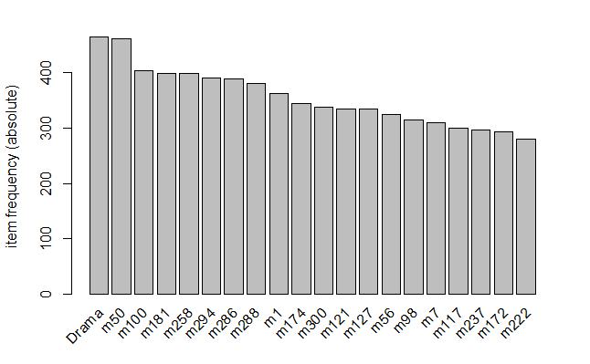

```r
itemFrequencyPlot(train_genre, 'absolute', topN = 20)
```

## Find Assocation between Transactions

Find association rules using apriori , with given *support=.20 and confidence = .80* and find all rules with minimum length of 2.

```r
rules <- apriori(train_genre, list(support = 0.20, confidence = 0.80, minlen = 2))
```

```
Apriori

Parameter specification:
 confidence minval smax arem  aval originalSupport maxtime support minlen
        0.8    0.1    1 none FALSE            TRUE       5     0.2      2
 maxlen target   ext
     10  rules FALSE

Algorithmic control:
 filter tree heap memopt load sort verbose
    0.1 TRUE TRUE  FALSE TRUE    2    TRUE

Absolute minimum support count: 150

set item appearances ...[0 item(s)] done [0.01s].
set transactions ...[1662 item(s), 754 transaction(s)] done [0.02s].
sorting and recoding items ... [134 item(s)] done [0.01s].
creating transaction tree ... done [0.00s].
checking subsets of size 1 2 3 4 5 6 done [0.05s].
writing ... [4827 rule(s)] done [0.01s].
creating S4 object  ... done [0.01s].
```

It found above *4827 rules* with given conditions.

## Extract the lhs and rhs of all rules and paste into list.

```r
rules_lhs = lhs(rules)
rules_rhs = rhs(rules)
rules_lhs.list = as(rules_lhs, 'list')
rules_rhs.list = as(rules_rhs, 'list')
```

## Filter RHS for only movie

Filter for movie like only consequent using regular expression, in which we search with movie-name start with “m” followed by digit.

```r
re.movie = '^m[0-9]+$'
movie_in_rhs = grepl(re.movie, rules_rhs.list)
```

## Display top 10 rules extracted w.r.t Lift

```r
inspect(head(sort(rules, by = "lift"), 10))
```

```
     lhs                     rhs    support   confidence lift     count
[1]  {m174,m181,m183}     => {m176} 0.2082228 0.8674033  2.843574 157
[2]  {m174,m181,m183,m50} => {m176} 0.2082228 0.8674033  2.843574 157
[3]  {m174,m195,m79}      => {m96}  0.2029178 0.9000000  2.839331 153
[4]  {m172,m174,m183,m50} => {m176} 0.2002653 0.8628571  2.828671 151
[5]  {m172,m174,m183}     => {m176} 0.2055703 0.8611111  2.822947 155
[6]  {m174,m176,m181,m50} => {m183} 0.2082228 0.8870056  2.821950 157
[7]  {m172,m176,m50}      => {m183} 0.2068966 0.8863636  2.819908 156
[8]  {m195,m50,m79}       => {m96}  0.2002653 0.8934911  2.818796 151
[9]  {m172,m174,m176,m50} => {m183} 0.2002653 0.8830409  2.809337 151
[10] {m195,m79}           => {m96}  0.2122016 0.8888889  2.804277 160
```

## Find Prediction from Subset

- Find the correct prediction from test data , using rules generated from train data.
- This code also take care of multi antecedent in rules as seen above this block.
- Code uses concept of *is.subset()* which will extract all subset from basket and match with lhs of rule and return a logical output .
- Also uses function *Reduce(fun,vector)*, whose main objective is to apply function given(here *fun = Union*) to the vector(here *vector = previous movie output*) and convert output as a Vector.

```r
correct = 0
total = 0
for (i in 1:test_genre.count) { # for each transaction (user) 189 records in test.
  # find rules with subset of Basket of test users covers using rule LHS.
  lhs_in_txn <- as.logical(is.subset(rules_lhs, test_genre[i]))
  # Find all rhs value from the rules where 2 condition satisfied:
  #     1. lhs is in subset of basket
  #     2. rhs is giving movies as result
  true_rules_rhs <- as(rules_rhs[lhs_in_txn & movie_in_rhs], 'list')
  # Combine all the movie result(union operation) and return as vector for user
  predictions = Reduce(union, true_rules_rhs, vector('character'))
  # increment correct and total predictions
  # Find correct if predicted movie present in original test data.
  correct = correct + sum(predictions %in% test_genre.list[[i]])
  #total will be updated for all the predictions done by engine
  total = total + length(predictions)
}
```

## Calculate the precision from above found variable correct and total.

```r
precision = correct / total
```

## Display the final result of accuracy and precision.

```r
cat('No. of test users: ', test_genre.count, '\n')
```

```
No. of test users:  189
```

```r
cat('Correct predictions: ', correct, '\n')
```

```
Correct predictions:  1698
```

```r
cat('Total predictions: ', total, '\n')
```

```
Total predictions:  2463
```

```r
cat('Precision: ', precision*100,'%', '\n')
```

```
Precision:  68.94032 %
```

## SUMMARY

- We have achieved accuracy for **~69%** , which is quite good for movie recommendation system.
- We have included all available details into the basket for generation of rules
- High lift from data with only like (~60%) to Current ~69%.